# time series analysis in R

**Covariance and correlation**

- Covariance
  - relationship between two variables that is scale dependent
- Correlation
  - standardized version of covariance
  - **+1**: perfectly positive linear relationship
  - **-1**: perfectly negative linear relationship
  - 0 : no linear relationship
  - cov(A, B) / (sd(A)*sd(B))

**Calculating sample covariances and correlations**

Sample covariances measure the strength of the linear relationship between matched pairs of variables. The `cov()` function can be used to calculate covariances for a pair of variables, or a covariance matrix when a matrix containing several variables is given as input. For the latter case, the matrix is symmetric with covariances between variables on the off-diagonal and variances of the variables along the diagonal. On the right you can see the scatterplot matrix of your `logreturns` data.

Covariances are very important throughout finance, but they are not scale free and they can be difficult to directly interpret. Correlation is the standardized version of covariance that ranges in value from -1 to 1, where values close to 1 in magnitude indicate a strong linear relationship between pairs of variables. The `cor()` function can be applied to both pairs of variables as well as a matrix containing several variables, and the output is interpreted analogously.

In this exercise, you’ll use `cov()` and `cor()` to explore your `logreturns` data.

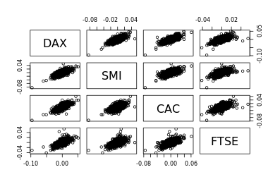

```r
DAX_logreturns <- diff(log(eu_stocks[,'DAX']))
FTSE_logreturns <- diff(log(eu_stocks[,'FTSE']))

# Use cov() with DAX_logreturns and FTSE_logreturns
cov(DAX_logreturns, FTSE_logreturns)
```

```
## [1] 5.241794e-05
```

```r
# Use cov() with logreturns
cov(logreturns)
```

```
##               DAX          SMI          CAC         FTSE
## DAX  1.061072e-04 6.699564e-05 8.345130e-05 5.241794e-05
## SMI  6.699564e-05 8.556317e-05 6.285881e-05 4.304517e-05
## CAC  8.345130e-05 6.285881e-05 1.216802e-04 5.693174e-05
## FTSE 5.241794e-05 4.304517e-05 5.693174e-05 6.332543e-05
```

```r
# Use cor() with DAX_logreturns and FTSE_logreturns
cor(DAX_logreturns, FTSE_logreturns)
```

```
## [1] 0.6394674
```

```r
# Use cor() with logreturns
cor(logreturns)
```

```
##            DAX       SMI       CAC      FTSE
## DAX  1.0000000 0.7031219 0.7344304 0.6394674
## SMI  0.7031219 1.0000000 0.6160454 0.5847791
## CAC  0.7344304 0.6160454 1.0000000 0.6485679
## FTSE 0.6394674 0.5847791 0.6485679 1.0000000
```

The `cov()` and `cor()` commands provide a simple and intuitive output for comparing the relationships between your indices, especially when a scatterplot matrix is difficult to interpret.

**Autocorrelation**

**Calculating autocorrelations**

Autocorrelations or lagged correlations are used to assess whether a time series is dependent on its past. For a time series `x` of length `n` we consider the `n-1` pairs of observations one time unit apart. The first such pair is `(x[2],x[1])`, and the next is `(x[3],x[2])`. Each such pair is of the form `(x[t],x[t-1])` where t is the observation index, which we vary from 2 to n in this case. The lag-1 autocorrelation of `x` can be estimated as the sample correlation of these `(x[t], x[t-1])` pairs.

In general, we can manually create these pairs of observations. First, create two vectors, `x_t0` and `x_t1`, each with length `n-1`, such that the rows correspond to `(x[t], x[t-1])` pairs. Then apply the `cor()` function to estimate the lag-1 autocorrelation.

Luckily, the [acf()](https://www.rdocumentation.org/packages/stats/versions/3.3.1/topics/acf) command provides a shortcut. Applying `acf(..., lag.max = 1, plot = FALSE)` to a series `x` automatically calculates the lag-1 autocorrelation.

Finally, note that the two estimates differ slightly as they use slightly different scalings in their calculation of sample covariance, `1/(n-1)` versus `1/n`. Although the latter would provide a biased estimate, it is preferred in time series analysis, and the resulting autocorrelation estimates only differ by a factor of `(n-1)/n`.

In this exercise, you’ll practice both the manual and automatic calculation of a lag-1 autocorrelation. The time series `x` and its length `n` (150) have already been loaded. The series is shown in the plot below.

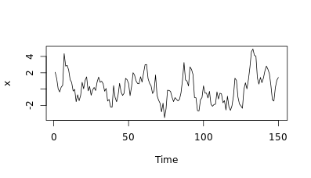

```
# Define x_t0 as x[-1]
x_t0 <- x[-1]

# Define x_t1 as x[-n]
x_t1 <- x[-n]

# Confirm that x_t0 and x_t1 are (x[t], x[t-1]) pairs
head(cbind(x_t0, x_t1))

######################################################
           x_t0       x_t1
[1,]  1.2996380  2.0655438
[2,]  0.0335780  1.2996380
[3,] -0.3425807  0.0335780
[4,]  0.2325613 -0.3425807
[5,]  0.4681201  0.2325613
[6,]  4.3411156  0.4681201
######################################################

# Plot x_t0 and x_t1
plot(x_t0, x_t1)

# View the correlation between x_t0 and x_t1
cor(x_t0, x_t1)

######################################################
[1] 0.7630314
######################################################

# Use acf with x
acf(x, lag.max = 1, plot = FALSE)

######################################################
Autocorrelations of series 'x', by lag

    0     1
1.000 0.758
######################################################

# Confirm that difference factor is (n-1)/n
cor(x_t1, x_t0) * (n-1)/n

######################################################
[1] 0.7579445
######################################################
```

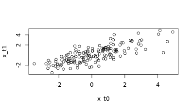

As you can see, the `acf()` command is a helpful shortcut for calculating autocorrelation. In the next few exercises, you’ll explore additional features of this command.

**The autocorrelation function**

Autocorrelations can be estimated at many lags to better assess how a time series relates to its past. We are typically most interested in how a series relates to its most recent past.

The `acf(..., lag.max = ..., plot = FALSE)` function will estimate all autocorrelations from 0, 1, 2,…, up to the value specified by the argument `lag.max`. In the previous exercise, you focused on the lag-1 autocorrelation by setting the `lag.max` argument to `1`.

In this exercise, you’ll explore some further applications of the `acf()` command. Once again, the time series`x` has been preloaded for you and is shown in the plot on the right.

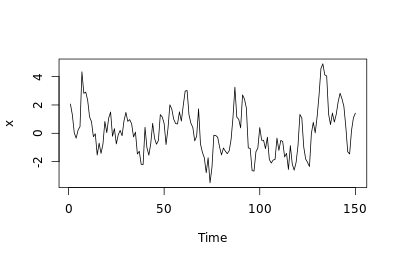

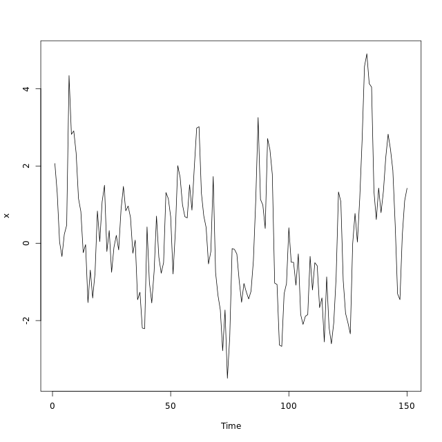

```
# Generate ACF estimates for x up to lag-10
acf(x, lag.max = 10, plot = FALSE)
```

```
Autocorrelations of series 'x', by lag

    0     1     2     3     4     5     6     7     8     9    10
1.000 0.758 0.537 0.345 0.227 0.198 0.140 0.114 0.124 0.118 0.100
```

```
# Type the ACF estimate at lag-10
0.100

# Type the ACF estimate at lag-5
0.198
```

Since autocorrelations may vary by lag, we often consider autocorrelations as a function of the time lag. Taking this view, we have now estimated the autocorrelation function (ACF) of `x` from lags 0 to 10.

**Visualizing the autocorrelation function**

Estimating the autocorrelation function (ACF) at many lags allows us to assess how a time series `x` relates to its past. The numeric estimates are important for detailed calculations, but it is also useful to visualize the ACF as a function of the lag.

In fact, the `acf()` command produces a figure by default. It also makes a default choice for `lag.max`, the maximum number of lags to be displayed.

Three time series `x`, `y`, and `z` have been loaded into your R environment and are plotted on the right. The time series `x` shows strong persistence, meaning the current value is closely relatively to those that proceed it. The time series `y` shows a periodic pattern with a cycle length of approximately four observations, meaning the current value is relatively close to the observation four before it. The time series `z` does not exhibit any clear pattern.

In this exercise, you’ll plot an estimated autocorrelation function for each time series. In the plots produced by `acf()`, the lag for each autocorrelation estimate is denoted on the horizontal axis and each autocorrelation estimate is indicated by the height of the vertical bars. Recall that the ACF at lag-0 is always 1.

Finally, each ACF figure includes a pair of blue, horizontal, dashed lines representing lag-wise 95% confidence intervals centered at zero. These are used for determining the statistical significance of an individual autocorrelation estimate at a given lag versus a null value of zero, i.e., no autocorrelation at that lag.

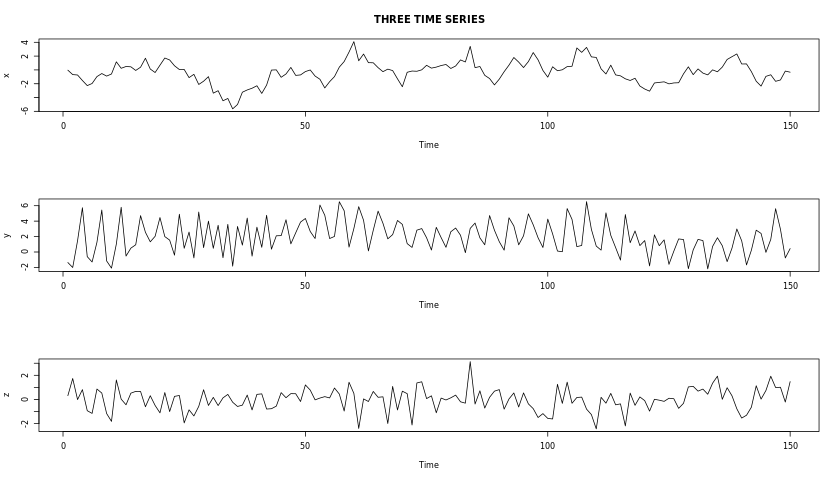

```
# View the ACF of x
acf(x)
```

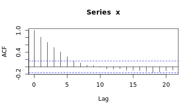

```
# View the ACF of y
acf(y)
```

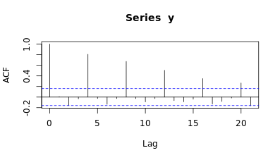

```
# View the ACF of z
acf(z)
```

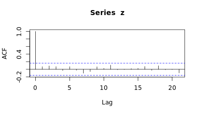

Plotting the estimated ACF of `x` shows large positive correlations for several lags which quickly decay towards zero. Plotting the estimated ACF of `y` shows large positive correlations at lags which are multiples of four, although these also decay towards zero as the lag multiple increases. Finally, the estimated ACF of `z` is near zero at all lags. It appears the series `z` is not linearly related to its past, at least through lag 20.

**The autoregressive model**

- The Autoregressive (AR) recursion:
  - $Today = Constant + Slope * Yesterday + Noise$
- Mean centered version
  - $(Today - Mean) = Slope * (Yesterday - Mean) + Noise$
  - $Y_t - \mu = \phi(Y_{t-1} - \mu) + \epsilon_t$ where $\epsilon_t$ is mean zero white noise (WN)
    - The mean $\mu$
    - The slope $\phi$
    - The WN variance $\sigma^2$
  - large values of $\phi$ lead to greater autocorrelation
  - negative values of $\phi$ result in oscillatory time series
- if $\mu$ = 0 and slope $\phi$ = 1, then:
  - $Y_t = Y_{t-1} + \epsilon_t$
  - Random Walk (RW) and $Y_i$ i **not** stationary in this case

**Simulate the autoregressive model** The autoregressive (AR) model is arguably the most widely used time series model. It shares the very familiar interpretation of a simple linear regression, but here each observation is regressed on the previous observation. The AR model also includes the white noise (WN) and random walk (RW) models examined in earlier chapters as special cases.

The versatile `arima.sim()` function used in previous chapters can also be used to simulate data from an AR model by setting the `model` argument equal to `list(ar = phi)` , in which `phi` is a slope parameter from the interval (-1, 1). We also need to specify a series length `n`.

In this exercise, you will use this command to simulate and plot three different AR models with slope parameters equal to 0.5, 0.9, and -0.75, respectively.

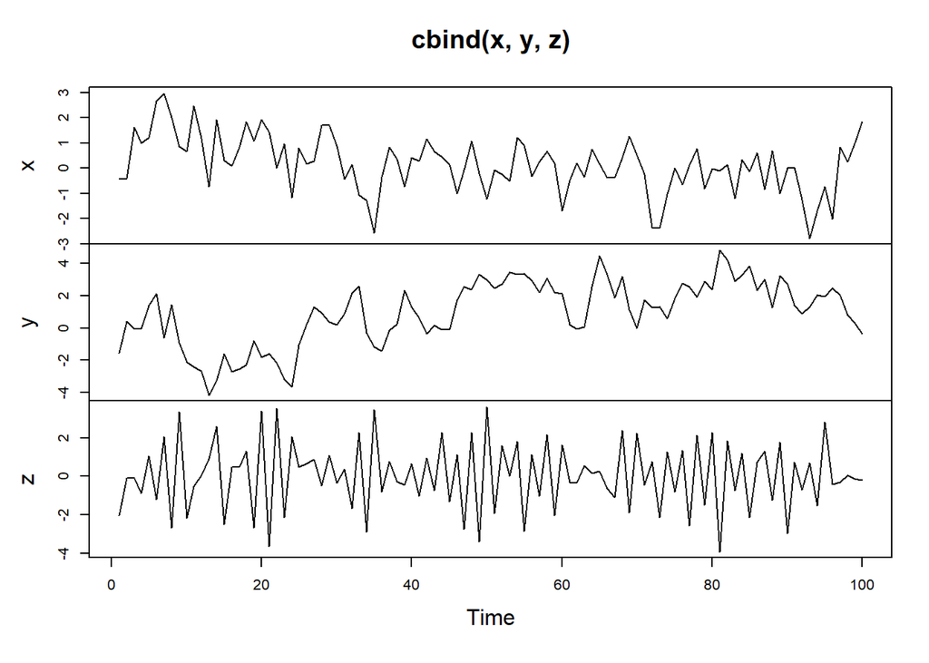

```r
# Simulate an AR model with 0.5 slope
x <- arima.sim(model = list(ar = 0.5), n = 100)

# Simulate an AR model with 0.9 slope
y <- arima.sim(model = list(ar = 0.9), n = 100)

# Simulate an AR model with -0.75 slope
z <- arima.sim(model = list(ar = -0.75), n = 100)

# Plot your simulated data
plot.ts(cbind(x, y, z))
```

As you can see, your `x` data shows a just a moderate amount of autocorrelation while your `y` data shows a large amount of autocorrelation. Alternatively, your `z` data tends to oscillate considerably from one observation to the next.

**Estimate the autocorrelation function (ACF) for an autoregression** What if you need to estimate the autocorrelation function from your data? To do so, you’ll need the **acf()** command, which estimates autocorrelation by exploring lags in your data. By default, this command generates a plot of the relationship between the current observation and lags extending backwards.

In this exercise, you’ll use the `acf()` command to estimate the autocorrelation function for three new simulated AR series (`x`, `y`, and `z`). These objects have slope parameters 0.5, 0.9, and -0.75, respectively.

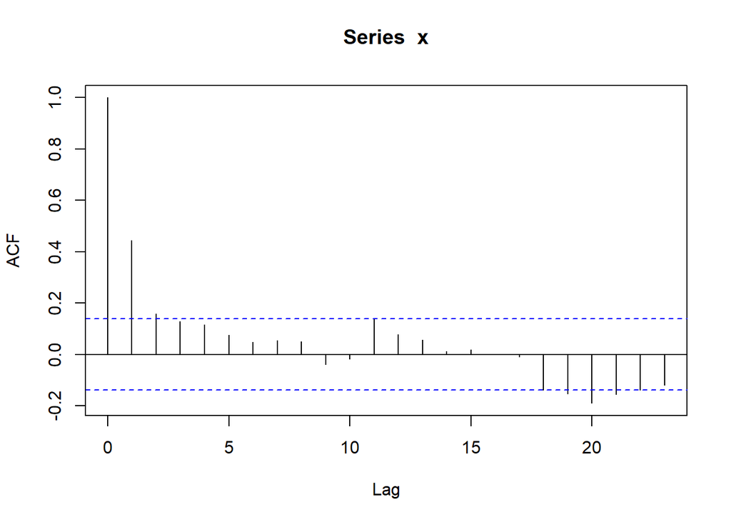

```r
# Simulate an AR model with 0.5 slope
x <- arima.sim(model = list(ar = 0.5), n = 200)

# Simulate an AR model with 0.9 slope
y <- arima.sim(model = list(ar = 0.9), n = 200)

# Simulate an AR model with -0.75 slope
z <- arima.sim(model = list(ar = -0.75), n = 200)

# Calculate the ACF for x
acf(x)
```

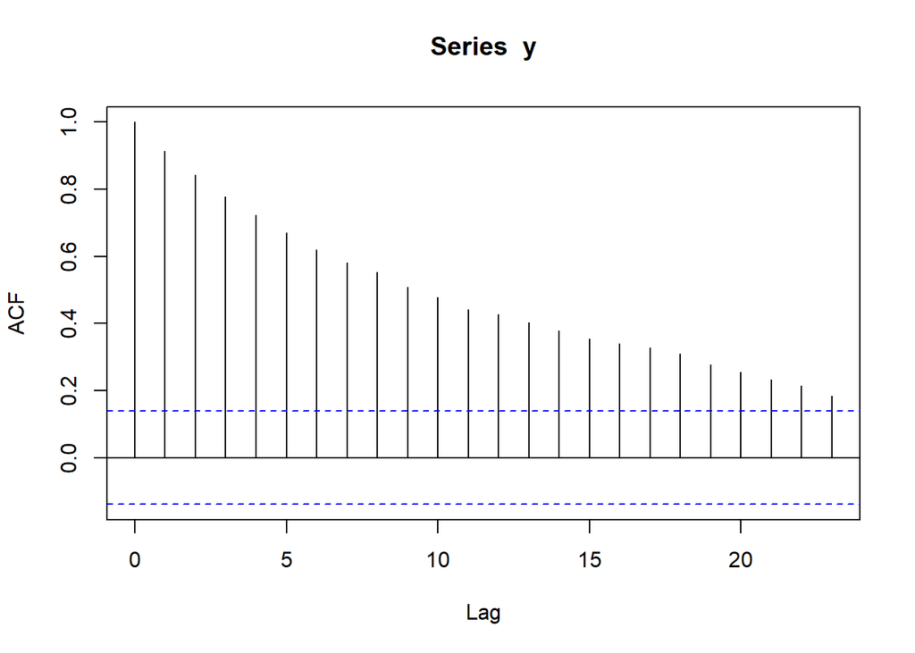

```r
# Calculate the ACF for y
acf(y)
```

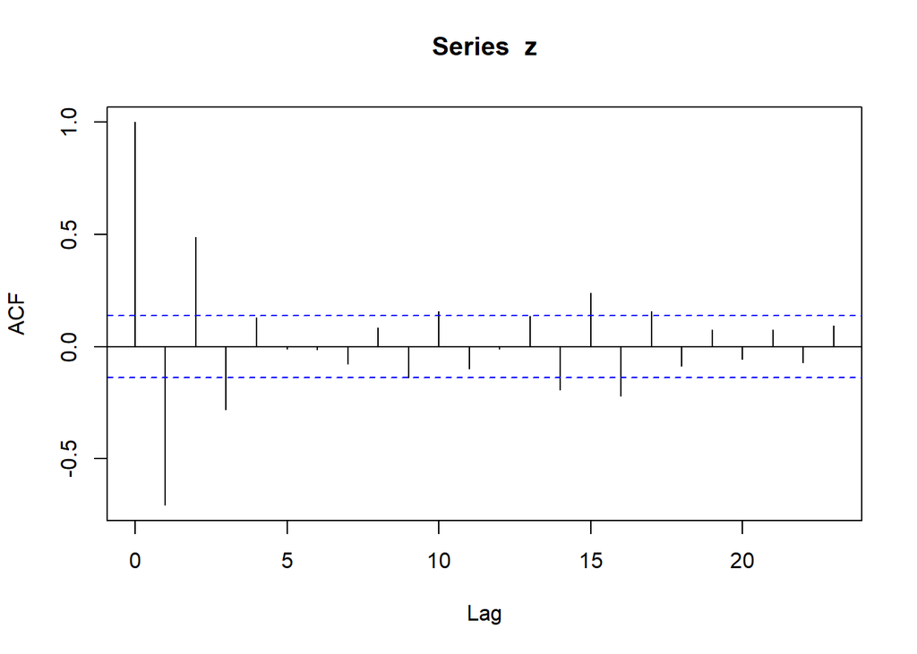

```r
# Calculate the ACF for z
acf(z)
```

The plots generated by the `acf()` command provide useful information about each lag of your time series. The first series `x` has positive autocorrelation for the first couple lags, but they quickly approach zero. The second series `y` has positive autocorrelation for many lags, but they also decay to zero. The last series `z` has an alternating pattern, as does its autocorrelation function (ACF), but its ACF still quickly decays to zero in magnitude.

**Compare the random walk (RW) and autoregressive (AR) models** The random walk (RW) model is a special case of the autoregressive (AR) model, in which the slope parameter is equal to `1`. Recall from previous chapters that the RW model is not stationary and exhibits very strong persistence. Its sample autocovariance function (ACF) also decays to zero very slowly, meaning past values have a long lasting impact on current values.

The stationary AR model has a slope parameter between -1 and 1. The AR model exhibits higher persistence when its slope parameter is closer to 1, but the process reverts to its mean fairly quickly. Its sample ACF also decays to zero at a quick (geometric) rate, indicating that values far in the past have little impact on future values of the process.

In this exercise, you’ll explore these qualities by simulating and plotting additional data from an AR model.

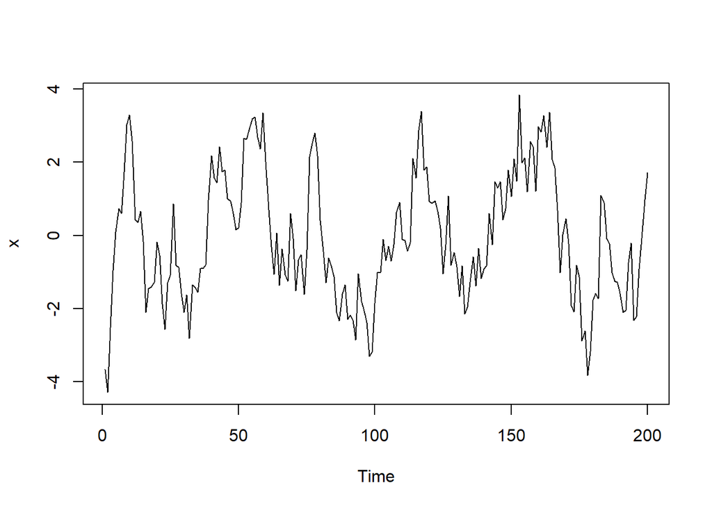

```r
# Simulate and plot AR model with slope 0.9
x <- arima.sim(model = list(ar = 0.9), n = 200)
ts.plot(x)
```

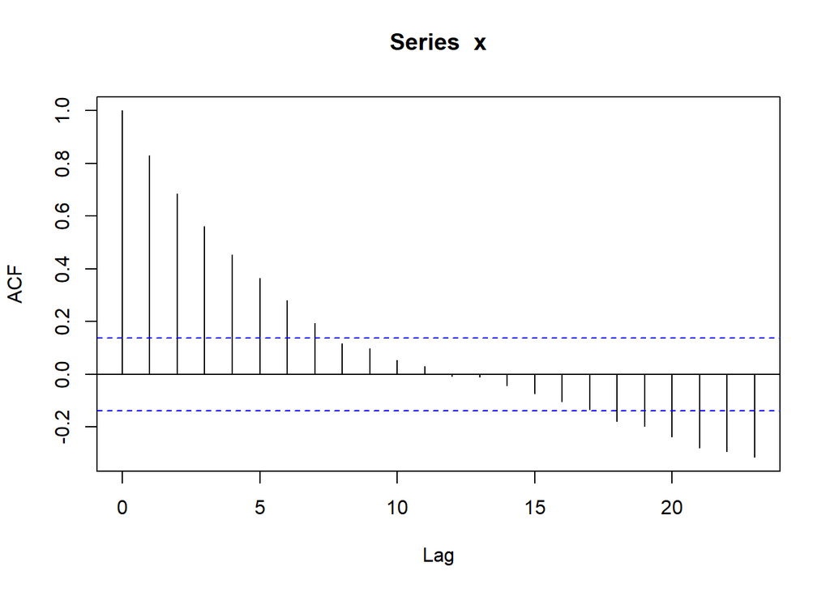

```r
acf(x)
```

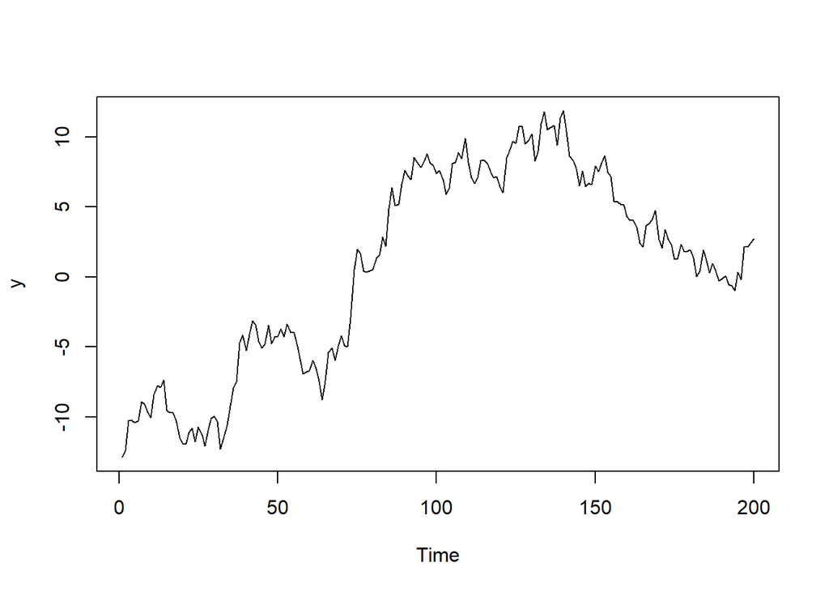

```r
# Simulate and plot AR model with slope 0.98
y <- arima.sim(model = list(ar = 0.98), n = 200)
ts.plot(y)
```

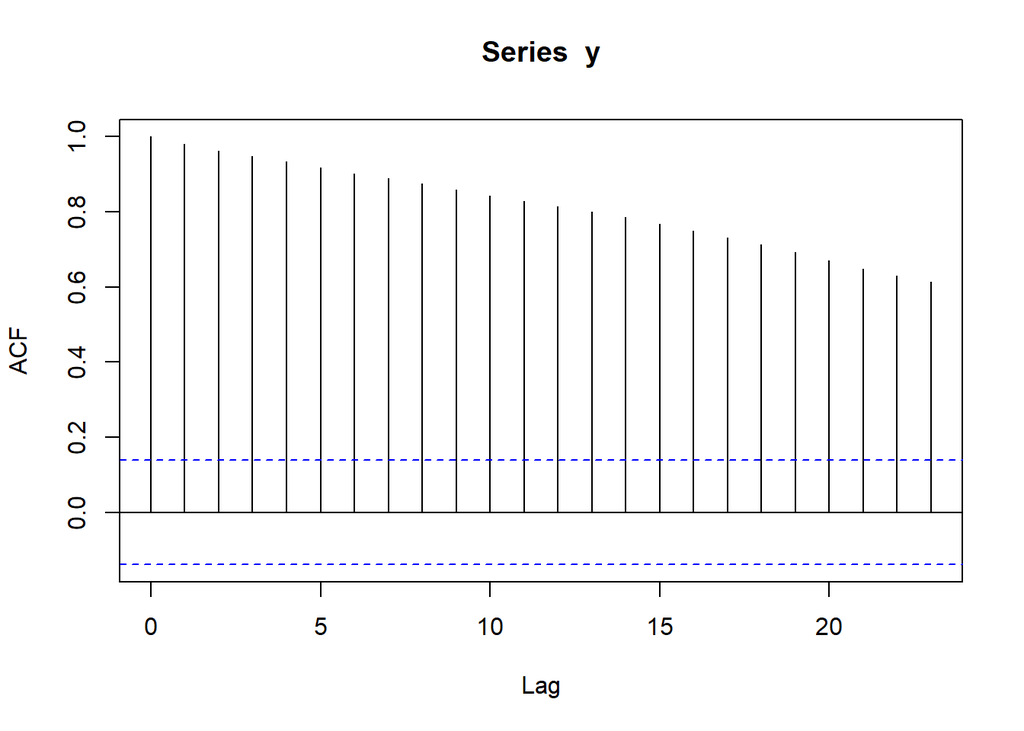

```r
acf(y)
```

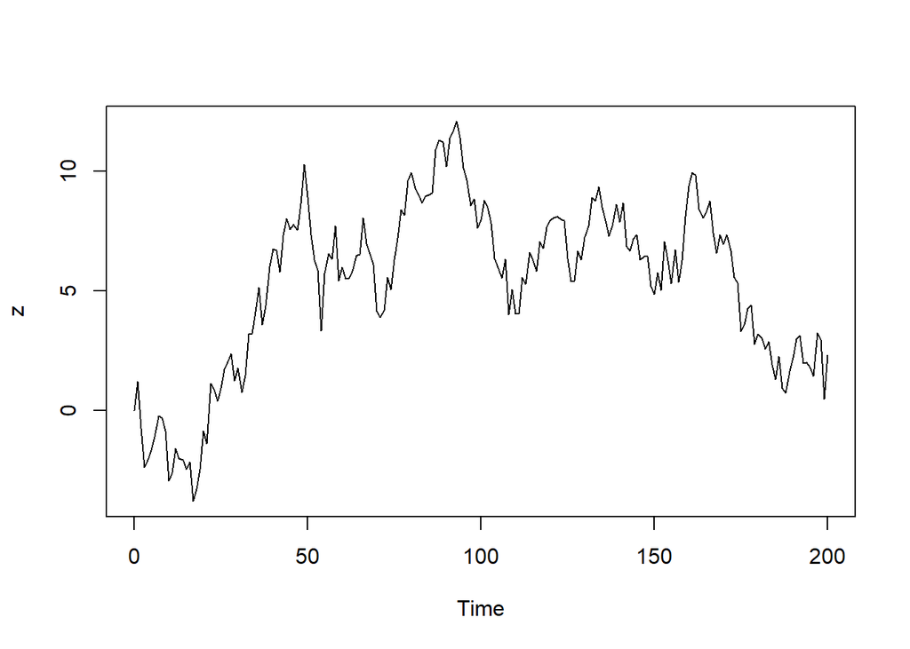

```r
# Simulate and plot RW model
z <- arima.sim(model = list(order=c(0,1,0)), n = 200)
ts.plot(z)
```

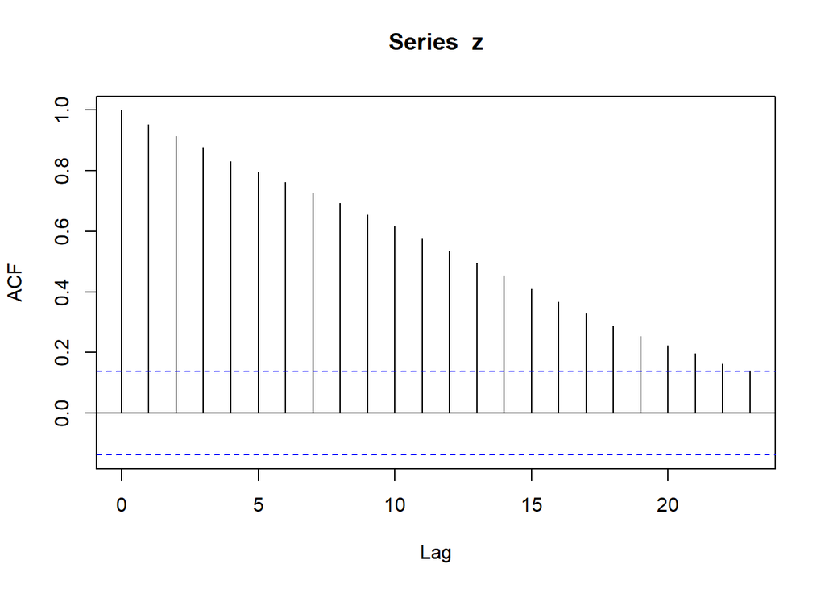

```r
acf(z)
```

**AR model estimation and forecasting**

ar1 = slope $\hat{\phi}$ intercept = $\hat{\mu}$ sigma^2 = $\hat{\sigma}^2_\epsilon$

- AR processes: fitted values
  - $\hat{Today} = \hat{Mean} + \hat{Slope} * (Yesterday - \hat{Mean})$
  - $\hat{Y}_t = \hat{\mu} + \hat{\phi}(Y_{t-1} - \hat{\mu})$
- Residuals = $Today - \hat{Today}$
  - $\hat{\epsilon}_t = Y_t - \hat{Y}_t$

**Estimate the autoregressive (AR) model** For a given time series `x` we can fit the autoregressive (AR) model using the `arima()` command and setting `order` equal to c(1, 0, 0). Note for reference that an AR model is an **ARIMA(1, 0, 0)** model.

In this exercise, you’ll explore additional qualities of the AR model by practicing the `arima()` command on a simulated time series `x` as well as the `AirPassengers` data. This command allows you to identify the estimated slope (`ar1`), mean (`intercept`), and innovation variance (`sigma^2`) of the model.

Both `x` and the `AirPassengers` data are preloaded in your environment. The time series `x` is shown in the figure below.

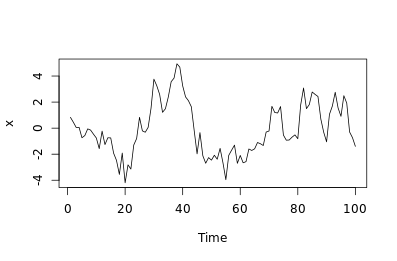

```
# Fit the AR model to x
arima(x, order = c(1, 0, 0))
```

```
Coefficients:
         ar1  intercept
      0.8575    -0.0948
s.e.  0.0491     0.6703

sigma^2 estimated as 1.022:  log likelihood = -143.66,  aic = 293.32
```

```
# Copy and paste the slope (ar1) estimate
0.8575

# Copy and paste the slope mean (intercept) estimate
-0.0948

# Copy and paste the innovation variance (sigma^2) estimate
1.022
```

```
# Fit the AR model to AirPassengers
AR <- arima(AirPassengers, order = c(1, 0, 0))
print(AR)
```

```
Call:
arima(x = AirPassengers, order = c(1, 0, 0))

Coefficients:
         ar1  intercept
      0.9646   278.4649
s.e.  0.0214    67.1141

sigma^2 estimated as 1119:  log likelihood = -711.09,  aic = 1428.18
```

```
# Run the following commands to plot the series and fitted values
ts.plot(AirPassengers)
```

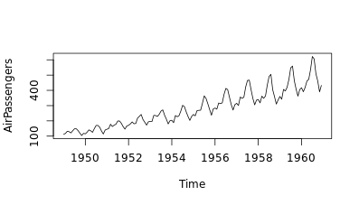

```
AR_fitted <- AirPassengers - residuals(AR)
points(AR_fitted, type = "l", col = 2, lty = 2)
```

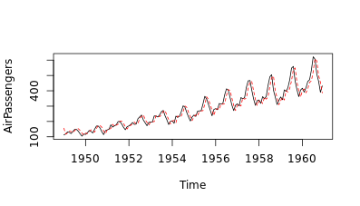

By fitting an AR model to the `AirPassengers` data, you’ve succesfully modeled the data in a reproducible fashion. This allows you to predict future observations based on your `AR_fitted` data.

**Simple forecasts from an estimated AR model** Now that you’ve modeled your data using the `arima()` command, you are ready to make simple forecasts based on your model. The **predict()** function can be used to make forecasts from an estimated AR model. In the object generated by your `predict()` command, the `$pred` value is the forecast, and the `$se` value is the standard error for the forecast.

To make predictions for several periods beyond the last observations, you can use the `n.ahead` argument in your `predict()` command. This argument establishes the forecast horizon (`h`), or the number of periods being forecast. The forecasts are made recursively from 1 to h-steps ahead from the end of the observed time series.

In this exercise, you’ll make simple forecasts using an AR model applied to the `Nile` data, which records annual observations of the flow of the River Nile from 1871 to 1970.

```r
# Fit an AR model to Nile
AR <- arima(Nile, order = c(1,0,0))
print(AR)
```

```
##
## Call:
## arima(x = Nile, order = c(1, 0, 0))
##
## Coefficients:
##          ar1  intercept
##       0.5063   919.5685
## s.e.  0.0867    29.1410
##
## sigma^2 estimated as 21125:  log likelihood = -639.95,  aic = 1285.9
```

```r
AR_fit <- Nile - residuals(AR)

# Use predict() to make a 1-step forecast
predict_AR <- predict(AR)

# Obtain the 1-step forecast using $pred[1]
predict_AR$pred[1]
```

```
## [1] 828.6576
```

```r
# Use predict to make 1-step through 10-step forecasts
predict(AR, n.ahead = 10)
```

```
## $pred
## Time Series:
## Start = 1971
## End = 1980
## Frequency = 1
##  [1] 828.6576 873.5426 896.2668 907.7715 913.5960 916.5448 918.0377 918.7935
##  [9] 919.1762 919.3699
##
## $se
## Time Series:
## Start = 1971
## End = 1980
## Frequency = 1
##  [1] 145.3439 162.9092 167.1145 168.1754 168.4463 168.5156 168.5334 168.5380
##  [9] 168.5391 168.5394
```

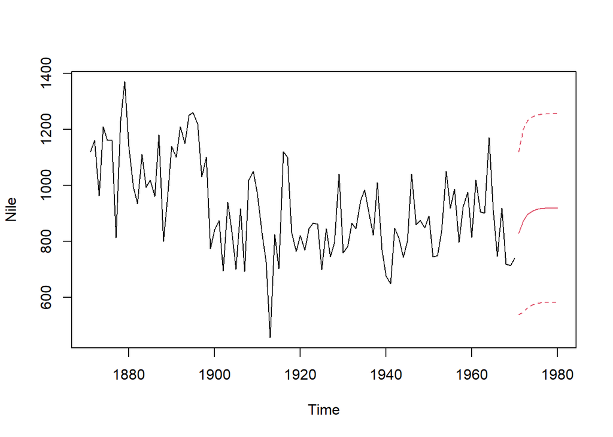

```r
# Run to plot the Nile series plus the forecast and 95% prediction intervals
ts.plot(Nile, xlim = c(1871, 1980))
AR_forecast <- predict(AR, n.ahead = 10)$pred
AR_forecast_se <- predict(AR, n.ahead = 10)$se
points(AR_forecast, type = "l", col = 2)
points(AR_forecast - 2*AR_forecast_se, type = "l", col = 2, lty = 2)
points(AR_forecast + 2*AR_forecast_se, type = "l", col = 2, lty = 2)
```

Your predictions of River Nile flow from 1971 to 1980 make sense based on the data you have. The relatively wide band of confidence (represented by the dotted lines) is a result of the low persistence in your `Nile` data.

**The simple moving average model**

- The simple moving average (MA) model:
  - $Today = Mean + Noise + Slope * (Yesterday's\ Noise)$
  - $Y_t = \mu + \epsilon_t + \theta\epsilon_{t-1}$ where $\epsilon_t$ is mean zero white noise (WN)
- Three parameters:
  - The mean $\mu$
  - The slope $\theta$
  - The WN variance $\sigma^2$
- if slope $\theta$ = 0 then it is a white noise (WN) process
- if slope $\theta$ is **not** zero then $Y_t$ depends on both $\epsilon_t$ and $\epsilon_{t-1}$
  - The process $Y_t$ is autocorrelated
- Large values of slope $\theta$ lead to greater autocorrelation
- Negative values of slope $\theta$ result in oscillatory time series

**Simulate the simple moving average model**

The simple moving average (MA) model is a parsimonious time series model used to account for very short-run autocorrelation. It does have a regression like form, but here each observation is regressed on the previous innovation, which is not actually observed. Like the autoregressive (AR) model, the MA model includes the white noise (WN) model as special case.

As with previous models, the MA model can be simulated using the `arima.sim()` command by setting the model argument to `list(ma = theta)`, where `theta` is a slope parameter from the interval (-1, 1). Once again, you also need to specify the series length using the `n` argument.

In this exercise, you’ll simulate and plot three MA models with slope parameters 0.5, 0.9, and -0.5, respectively.

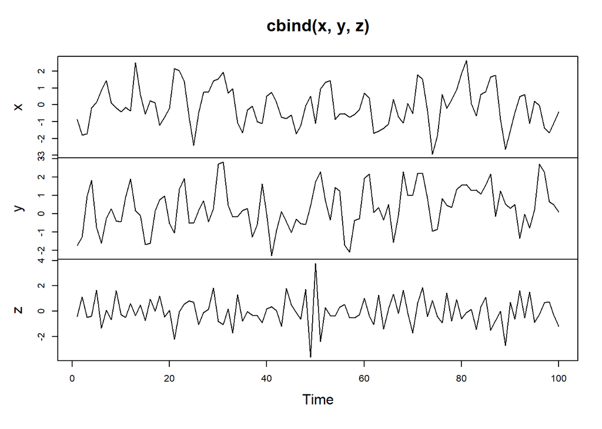

```r
# Generate MA model with slope 0.5
x <- arima.sim(model = list(ma = 0.5), n = 100)

# Generate MA model with slope 0.9
y <- arima.sim(model = list(ma = 0.9), n = 100)

# Generate MA model with slope -0.5
z <- arima.sim(model = list(ma = -0.5), n = 100)

# Plot all three models together
plot.ts(cbind(x, y, z))
```

Note that there is some very short-run persistence for the positive slope values (`x` and `y`), and the series has a tendency to alternate when the slope value is negative (`z`).

**Estimate the autocorrelation function (ACF) for a moving average** Now that you’ve simulated some MA data using the `arima.sim()` command, you may want to estimate the autocorrelation functions (ACF) for your data. As in the previous chapter, you can use the `acf()` command to generate plots of the autocorrelation in your MA data.

In this exercise, you’ll use `acf()` to estimate the ACF for three simulated MA series, `x`, `y`, and `z`. These series have slope parameters of 0.4, 0.9, and -0.75, respectively.

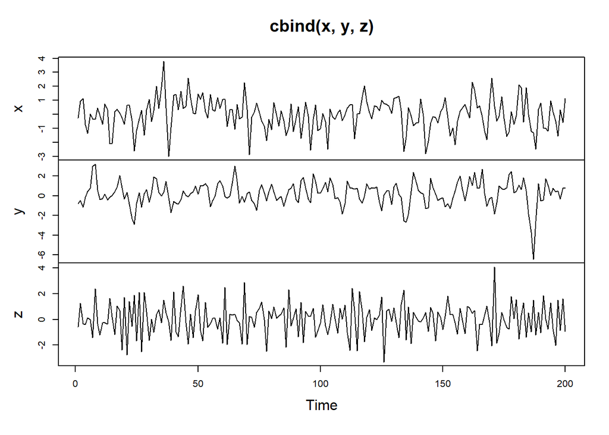

```r
# Generate MA model with slope 0.4
x <- arima.sim(model = list(ma = 0.4), n = 200)

# Generate MA model with slope 0.9
y <- arima.sim(model = list(ma = 0.9), n = 200)

# Generate MA model with slope -0.75
z <- arima.sim(model = list(ma = -0.75), n = 200)

# Plot all three models together
plot.ts(cbind(x, y, z))
```

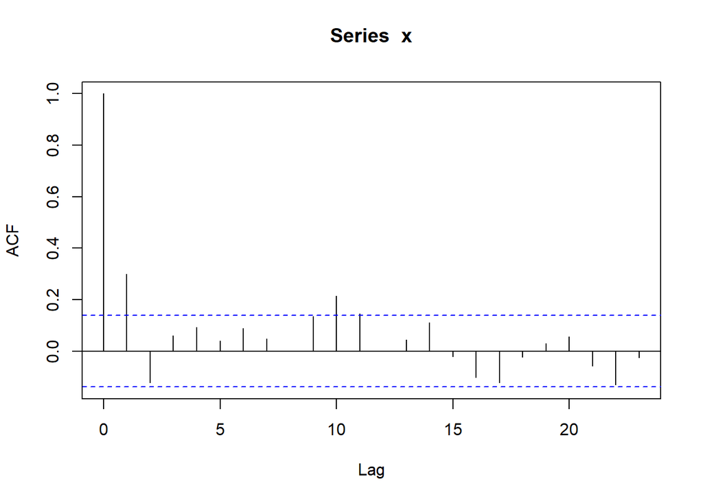

```r
# Calculate ACF for x
acf(x)
```

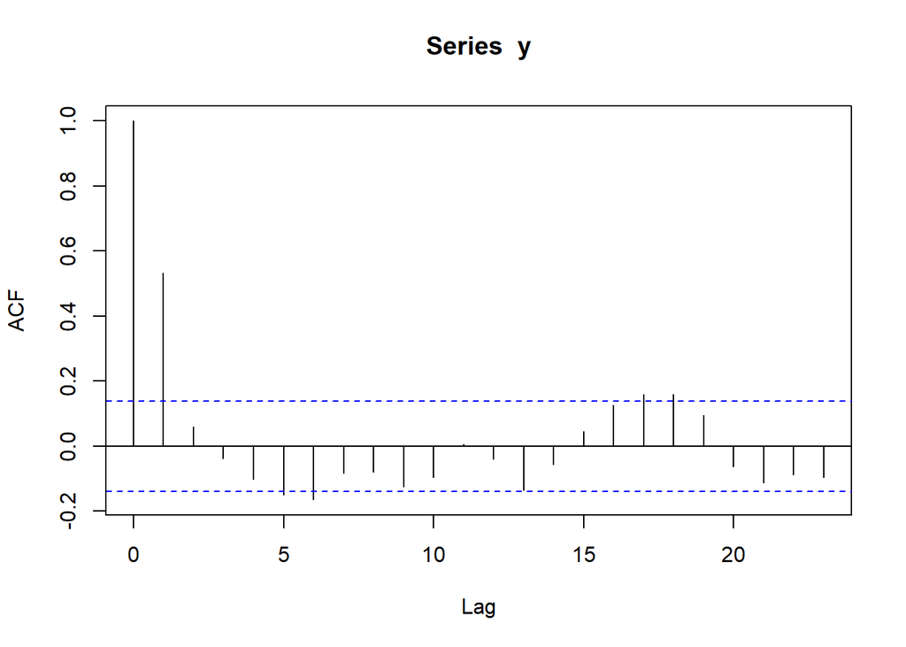

```r
# Calculate ACF for y
acf(y)
```

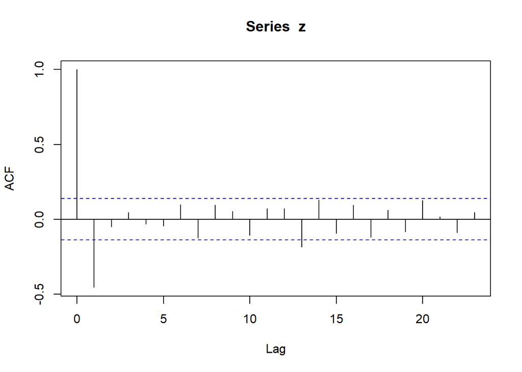

```r
# Calculate ACF for z
acf(z)
```

As you can see from your ACF plots, the series `x` has positive sample autocorrelation at the first lag, but it is approximately zero at other lags. The series `y` has a larger sample autocorrelation at its first lag, but it is also approximately zero for the others. The series `z` has an alternating pattern, and its sample autocorrelation is negative at the first lag. However, similar to the others, it is approximately zero for all higher lags.

**MA model estimation and forecasting**

- ma1 = $\hat{\theta}$
- intercept = $\hat{\mu}$
- sigma^2 = $\hat{\sigma}^2_\epsilon$
- MA fitted values:
  - $\hat{Today} = \hat{Mean} + \hat{Slope} * \hat{Yesterday's\ Noise}$
  - $\hat{Y}_t = \hat{\mu} + \hat{\theta}\hat{\epsilon}_{t-1}$
- Residuals:
  - $Today - \hat{Today}$
  - $\hat{\epsilon}_t = Y_t - \hat{Y}_t$

**Estimate the simple moving average model**

Now that you’ve simulated some MA models and calculated the ACF from these models, your next step is to fit the simple moving average (MA) model to some data using the `arima()` command. For a given time series `x` we can fit the simple moving average (MA) model using `arima(..., order = c(0, 0, 1))`. Note for reference that an MA model is an **ARIMA(0, 0, 1)** model.

In this exercise, you’ll practice using a preloaded time series (`x`, shown in the plot below) as well as the `Nile` dataset used in earlier chapters.

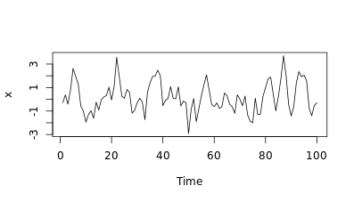

```
# Fit the MA model to `x`
arima(x, order = c(0, 0, 1))
```

```
Coefficients:
         ma1  intercept
      0.7928     0.1589
s.e.  0.0902     0.1747

sigma^2 estimated as 0.9576:  log likelihood = -140.22,  aic = 286.44
```

```
# Paste the slope (ma1) estimate below
0.7928

# Paste the slope mean (intercept) estimate below
0.1589

# Paste the innovation variance (sigma^2) estimate below
0.9576
```

```r
# Fit the MA model to Nile
MA <- arima(Nile, order = c(0, 0, 1))
print(MA)
```

```
##
## Call:
## arima(x = Nile, order = c(0, 0, 1))
##
## Coefficients:
##          ma1  intercept
##       0.3783   919.2433
## s.e.  0.0791    20.9685
##
## sigma^2 estimated as 23272:  log likelihood = -644.72,  aic = 1295.44
```

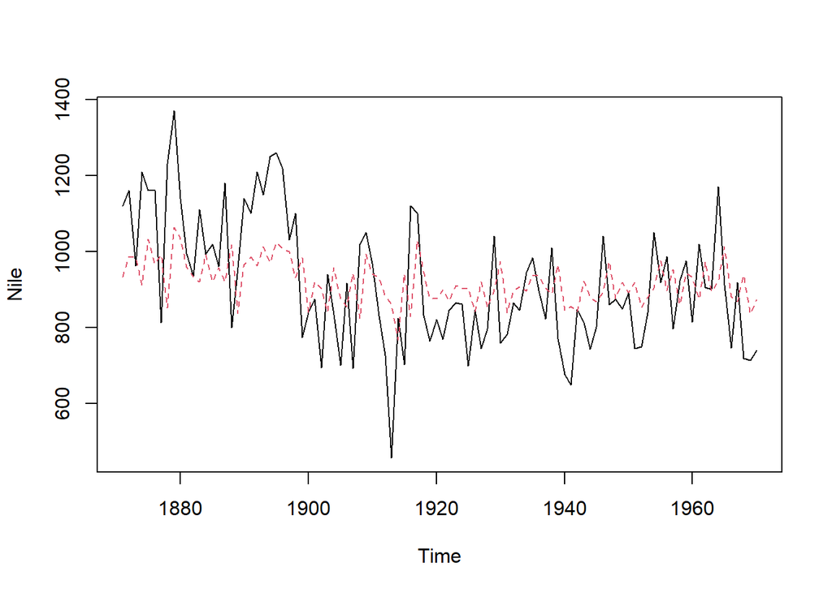

```r
# Plot Nile and MA_fit
ts.plot(Nile)
MA_fit <- Nile - resid(MA)
points(MA_fit, type = "l", col = 2, lty = 2)
```

By fitting an MA model to your `Nile` data, you’re able to capture variation in the data for future prediction. Based on the plot you’ve generated, does the MA model appear to be a strong fit for the `Nile` data?

**Simple forecasts from an estimated MA model**

Now that you’ve estimated a MA model with your `Nile` data, the next step is to do some simple forecasting with your model. As with other types of models, you can use the `predict()` function to make simple forecasts from your estimated MA model. Recall that the `$pred` value is the forecast, while the `$se` value is a standard error for that forecast, each of which is based on the fitted MA model.

Once again, to make predictions for several periods beyond the last observation you can use the `n.ahead = h` argument in your call to `predict()`. The forecasts are made recursively from 1 to h-steps ahead from the end of the observed time series. However, note that except for the 1-step forecast, all forecasts from the MA model are equal to the estimated mean (`intercept`).

In this exercise, you’ll use the `MA` model derived from your `Nile` data to make simple forecasts about future River Nile flow levels. Your `MA` model from the previous exercise is available in your environment.

```r
# Make a 1-step forecast based on MA
predict_MA <- predict(MA)

# Obtain the 1-step forecast using $pred[1]
predict_MA$pred[1]
```

```
## [1] 868.8747
```

```r
# Make a 1-step through 10-step forecast based on MA
predict(MA, n.ahead = 10)
```

```
## $pred
## Time Series:
## Start = 1971
## End = 1980
## Frequency = 1
##  [1] 868.8747 919.2433 919.2433 919.2433 919.2433 919.2433 919.2433 919.2433
##  [9] 919.2433 919.2433
##
## $se
## Time Series:
## Start = 1971
## End = 1980
## Frequency = 1
##  [1] 152.5508 163.1006 163.1006 163.1006 163.1006 163.1006 163.1006 163.1006
##  [9] 163.1006 163.1006
```

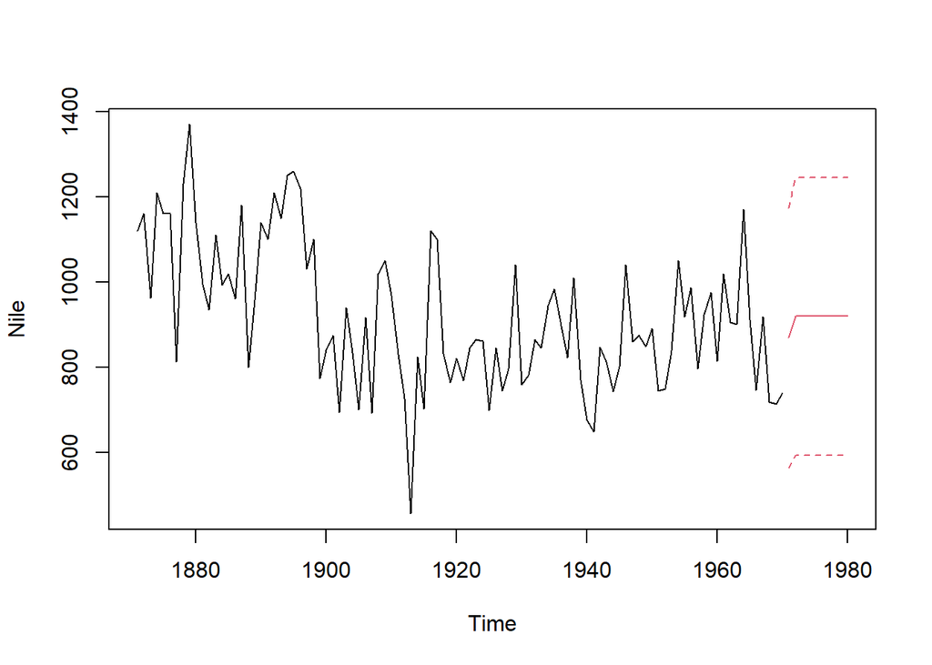

```r
# Plot the Nile series plus the forecast and 95% prediction intervals
ts.plot(Nile, xlim = c(1871, 1980))
MA_forecasts <- predict(MA, n.ahead = 10)$pred
MA_forecast_se <- predict(MA, n.ahead = 10)$se
points(MA_forecasts, type = "l", col = 2)
points(MA_forecasts - 2*MA_forecast_se, type = "l", col = 2, lty = 2)
points(MA_forecasts + 2*MA_forecast_se, type = "l", col = 2, lty = 2)
```

Note that the MA model can only produce a 1-step forecast. For additional forecasting periods, the `predict()` command simply extends the original 1-step forecast. This explains the unexpected horizontal lines after 1971.

**Compare AR and MA models**

Goodness of fit: - information criterion (aic and bic) measures in model fitting outputs help to compare which model best fits - lower values indicates better fitting model

**AR vs MA models**

As you’ve seen, autoregressive (AR) and simple moving average (MA) are two useful approaches to modeling time series. But how can you determine whether an AR or MA model is more appropriate in practice?

To determine model fit, you can measure the Akaike information criterion (AIC) and Bayesian information criterion (BIC) for each model. While the math underlying the AIC and BIC is beyond the scope of this course, for your purposes the main idea is these indicators penalize models with more estimated parameters, to avoid overfitting, and smaller values are preferred. All factors being equal, a model that produces a lower AIC or BIC than another model is considered a better fit.

To estimate these indicators, you can use the [AIC()](https://www.rdocumentation.org/packages/stats/versions/3.3.1/topics/AIC) and [BIC()](https://www.rdocumentation.org/packages/stats/versions/3.3.1/topics/AIC) commands, both of which require a single argument to specify the model in question.

In this exercise, you’ll return to the `Nile` data and the `AR` and `MA` models you fitted to this data. These models and their predictions for the 1970s (AR_fit) and (MA_fit) are depicted in the plot on the right.

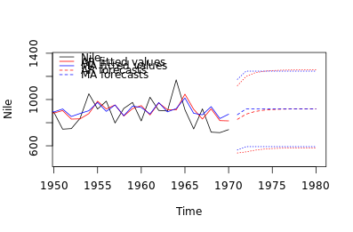

```r
# Find correlation between AR_fit and MA_fit
cor(AR_fit, MA_fit)
```

```
## [1] 0.9401765
```

```r
# Find AIC of AR
AIC(AR)
```

```
## [1] 1285.904
```

```r
# Find AIC of MA
AIC(MA)
```

```
## [1] 1295.442
```

```r
# Find BIC of AR
BIC(AR)
```

```
## [1] 1293.72
```

```r
# Find BIC of MA
BIC(MA)
```

```
## [1] 1303.257
```

Although the predictions from both models are very similar (indeed, they have a correlation coefficient of 0.94), both the AIC and BIC indicate that the AR model is a slightly better fit for your `Nile` data.

**Notes on models**

- the RW and AR models should show strong persistence
- The MA model shows short-run dependence but reverts quickly to the mean
- the WN model does not show any clear patterns.

**Notes on autocorrelation**:

- autocorrelation for the first lag only is consistent with the expectations of the MA model
- autocorrelation across several lags is consistent with the AR model
- considerable autocorrelation for many lags is consistent with a RW model.
- no autocorrelation is consistent with a WN model.

**Congratulations**

- What you’ve learned
  - manipulating `ts` objects, including `log()` and `diff()`
  - time series models: white noise, random walk, autoregression, simple moving average
  - time series simulation (`arima.sim()`), fitting (`arima`) and forecasting (`predict`)